# Part I - Prosper Dataset Exploration

## Introduction

> The Prosper data set contains 113,937 loans with 81 variables on each loan, including loan amount, borrower rate (or interest rate), current loan status, borrower income, and many others.

## Preliminary Wrangling

```python
# import all packages and set plots to be embedded inline
import numpy as np
import pandas as pd
import matplotlib.pyplot as plt
import seaborn as sb

%matplotlib inline
```

```python
df=pd.read_csv('prosperLoanData.csv')
df.head()
```

|  | ListingKey | ListingNumber | ListingCreationDate | CreditGrade | Term | LoanStatus | ClosedDate | BorrowerAPR | BorrowerRate | LenderYield | ... | LP_ServiceFees | LP_CollectionFees | LP_GrossPrincipalLoss | LP_NetPrincipalLoss | LP_NonPrincipalRecoverypayments | PercentFunded | Recommendations | InvestmentFromFriendsCount | InvestmentFromFriendsAmount | Investors |
| --- | --- | --- | --- | --- | --- | --- | --- | --- | --- | --- | --- | --- | --- | --- | --- | --- | --- | --- | --- | --- | --- |
| 0 | 1021339766868145413AB3B | 193129 | 2007-08-26 19:09:29.263000000 | C | 36 | Completed | 2009-08-14 00:00:00 | 0.16516 | 0.1580 | 0.1380 | ... | -133.18 | 0.0 | 0.0 | 0.0 | 0.0 | 1.0 | 0 | 0 | 0.0 | 258 |
| 1 | 10273602499503308B223C1 | 1209647 | 2014-02-27 08:28:07.900000000 | NaN | 36 | Current | NaN | 0.12016 | 0.0920 | 0.0820 | ... | 0.00 | 0.0 | 0.0 | 0.0 | 0.0 | 1.0 | 0 | 0 | 0.0 | 1 |
| 2 | 0EE9337825851032864889A | 81716 | 2007-01-05 15:00:47.090000000 | HR | 36 | Completed | 2009-12-17 00:00:00 | 0.28269 | 0.2750 | 0.2400 | ... | -24.20 | 0.0 | 0.0 | 0.0 | 0.0 | 1.0 | 0 | 0 | 0.0 | 41 |
| 3 | 0EF5356002482715299901A | 658116 | 2012-10-22 11:02:35.010000000 | NaN | 36 | Current | NaN | 0.12528 | 0.0974 | 0.0874 | ... | -108.01 | 0.0 | 0.0 | 0.0 | 0.0 | 1.0 | 0 | 0 | 0.0 | 158 |
| 4 | 0F023589499656230C5E3E2 | 909464 | 2013-09-14 18:38:39.097000000 | NaN | 36 | Current | NaN | 0.24614 | 0.2085 | 0.1985 | ... | -60.27 | 0.0 | 0.0 | 0.0 | 0.0 | 1.0 | 0 | 0 | 0.0 | 20 |

5 rows × 81 columns

```python
df.info()
```

```
<class 'pandas.core.frame.DataFrame'>
RangeIndex: 113937 entries, 0 to 113936
Data columns (total 81 columns):
 #   Column                               Non-Null Count   Dtype
---  ------                               --------------   -----
 0   ListingKey                           113937 non-null  object
 1   ListingNumber                        113937 non-null  int64
 2   ListingCreationDate                  113937 non-null  object
 3   CreditGrade                          28953 non-null   object
 4   Term                                 113937 non-null  int64
 5   LoanStatus                           113937 non-null  object
 6   ClosedDate                           55089 non-null   object
 7   BorrowerAPR                          113912 non-null  float64
 8   BorrowerRate                         113937 non-null  float64
 9   LenderYield                          113937 non-null  float64
```

[output cut: 73 more lines]

### What is the structure of your dataset?

> The dataset has 81 variables and 113,937 records capturing information on loans disbursed by Prosper Bank. Some of the features relate to the characteristics of the borrower at the time the account was opened.

### What is/are the main feature(s) of interest in your dataset?

> I am interested in finding out if the risk rating (ProsperScore) is being assigned correctly to borrowers and in understanding the relationship between the risk score and the other variables in the dataset. I will focus on the loans that have resulted in a net loss for the bank. I will be using the feature LP_NetPrincipalLoss to filter out this population.

### What features in the dataset do you think will help support your investigation into your feature(s) of interest?

> Features that relate to how the borrower manages existing credit such as the DebtToIncomeRatio, BankcardUtilization, CurrentDelinquencies, TotalTrades, TradesNeverDelinquent,TradesOpenedLast6Months, OpenRevolvingAccounts and TotalProsperLoans. Other interesting features relating to the borrower could be IncomeRange, ProsperScore, Occupation and EmploymentStatusDuration. Features of interest relating to the loan could be LoanMonthsSinceOrigination, LoanOriginalAmount and Term.

## Univariate Exploration

```python
Loss_df=df[df['LP_NetPrincipalLoss']>0]
```

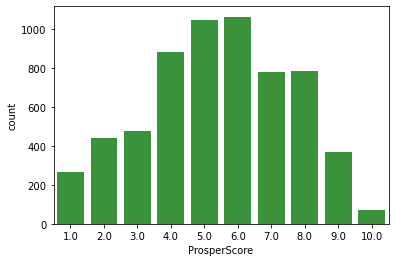

```python
#what does the score distribution of clients look like?
def plot_uni_bar(var):
    sb.countplot(data=Loss_df,x=var,color=sb.color_palette()[2]);

plot_uni_bar('ProsperScore')
```

The score dsitribution is bell shaped, with most customers scoring at the middle of the distribution and very few customers at the lower and upper tails. This is typical of any scoring distribution.

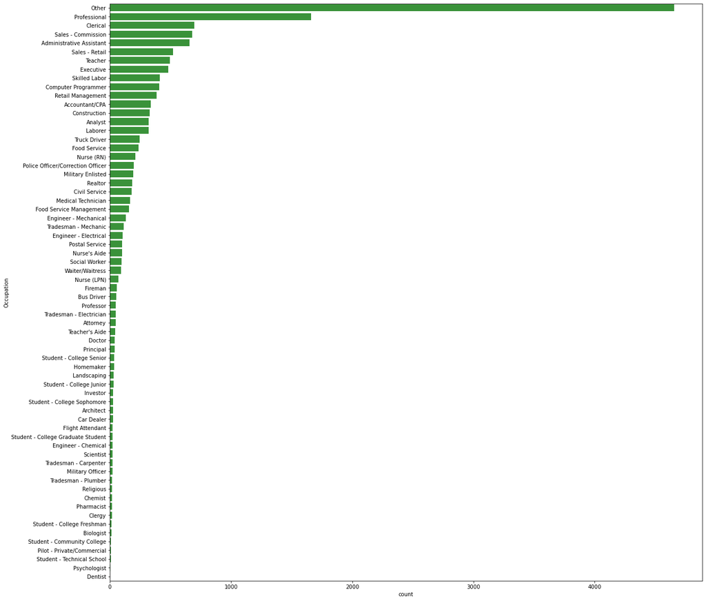

```python
#what kind of occupation do the borrowers have?
pd.unique(Loss_df['Occupation'])

occupation_order=Loss_df['Occupation'].value_counts().index

plt.figure(figsize=[20,20])
sb.countplot(data=Loss_df,y='Occupation',color=sb.color_palette()[2],order=occupation_order);
```

The list of occupations selected by borrowers is long, but not exhaustive. It is not surprising that most borrowers listed their occupation as other. It's also interesting that professional jobs like Teaching, Analsyt, Computer programmer, Accountant are high on the list of borrower occupations.

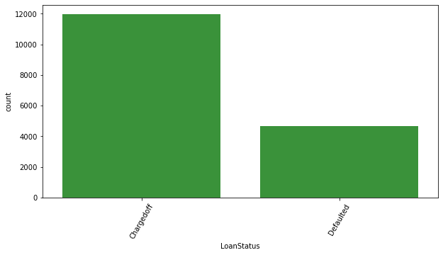

```python
plt.figure(figsize=[10, 5])
sorted_status=Loss_df.LoanStatus.value_counts().index
sb.countplot(data=Loss_df, x='LoanStatus', order=sorted_status,color=sb.color_palette()[2])
plt.xticks(rotation=60);
```

Most loans on the dataset are either chargedoff or defaulted, as one would expect.

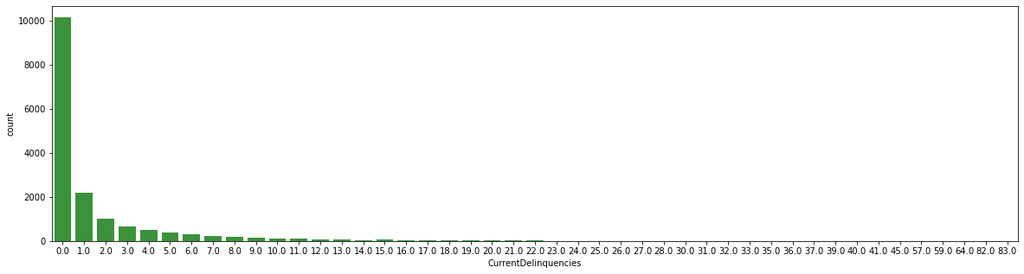

```python
#Current delinquencies indicates the number of accounts delinquent at the time the credit profile was pulled.
plt.figure(figsize=[20,5])
plot_uni_bar('CurrentDelinquencies')
#plt.xlim(0,20)
```

The deliqnuency distribution is skewed right and has a very long tail. It makes sense that most borrowers had good performance at the start of the loan agreement.

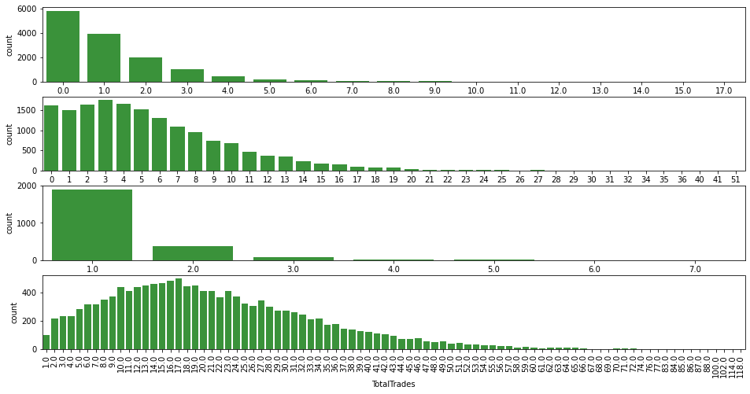

```python
#TotalProsperLoans,TotalTrades,OpenRevolvingAccounts,TradesOpenedLast6Months all show the count of number
#of credit lines opened, I will plot the four features in one chart
plt.figure(figsize=[16,8])
plt.subplot(4,1,1)
plot_uni_bar('TradesOpenedLast6Months')
plt.subplot(4,1,2)
plot_uni_bar('OpenRevolvingAccounts')
plt.subplot(4,1,3)
plot_uni_bar('TotalProsperLoans')
plt.subplot(4,1,4)
plot_uni_bar('TotalTrades')
plt.xticks(rotation=90);
```

The count distributions are all skewed right. Looking at the first and third chart, it seems customers who are the highest risk are those without an existng account or have at most 1 or 2 tradelines opened.

```
count    13597.000000
mean        80.140399
std         85.018970
min          0.000000
25%         19.000000
50%         51.000000
75%        112.000000
max        755.000000
Name: EmploymentStatusDuration, dtype: float64
```

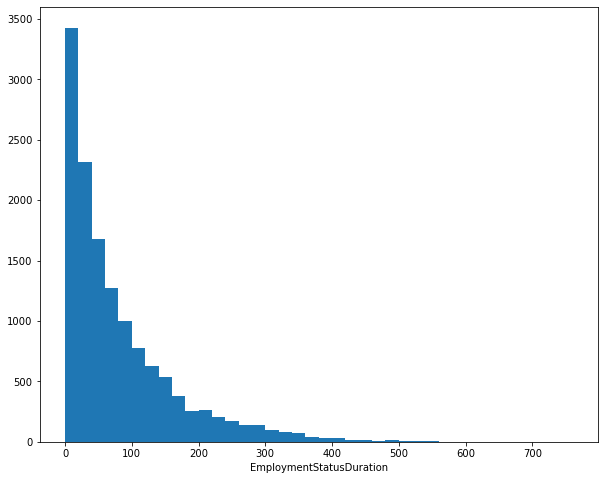

```python
#Distribution of EmploymentStatusDuration
print(Loss_df.EmploymentStatusDuration.describe())

def uni_hist(var,binsize):
    plt.figure(figsize=(10,8))
    bins = np.arange(min(Loss_df[var]), max(Loss_df[var])+binsize, binsize)
    plt.hist(data = Loss_df, x = var, bins = bins)
    plt.xlabel('{}'.format(var))

uni_hist('EmploymentStatusDuration',20)
```

It seems the longer a borrower has been employed the less likely they are to default on their payments.

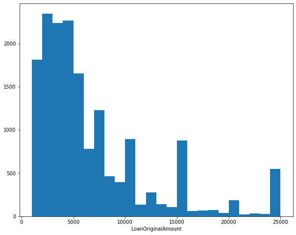

```python
#How is the Loan amount distributed
uni_hist('LoanOriginalAmount',1000)
```

The loan amount distribution is skewed right, with spikes at mutlples of 5000 i.e. 10000, 15000, 20000 and 25000.

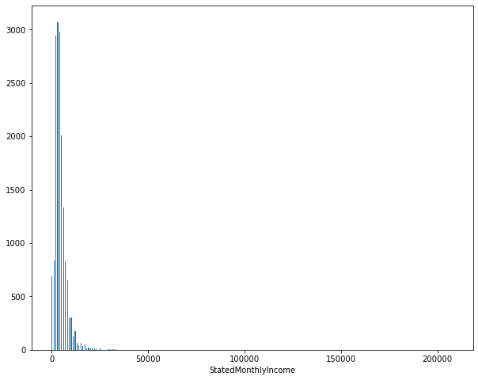

```python
#how is the borrower income distributed?
uni_hist('StatedMonthlyIncome',500)
```

The income range is wide, ranging from 0 to roughly 200,000, however the income distribution mostly lies on the left of the chart with a large majority of borrowers having an income less than 25,000. This suggests that we have outliers in the income distribution.

```python
High_income=Loss_df[Loss_df['StatedMonthlyIncome']> 50000]
High_income.StatedMonthlyIncome.sort_values()
```

```
62864      51000
89928      52000
91942      52000
65042      54000
15814      59000
50126      60000
100431     70000
78431     103000
8870      208000
Name: StatedMonthlyIncome, dtype: int64
```

Since we only have 2 values above 100000, we can limit the income feature to 100000, without changing the distribution significantly.

```python
Loss_df=Loss_df.loc[Loss_df['StatedMonthlyIncome']<100000]
```

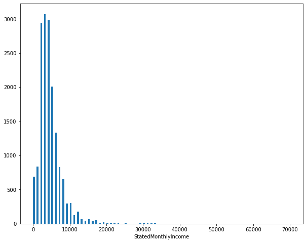

```python
uni_hist('StatedMonthlyIncome',500)
```

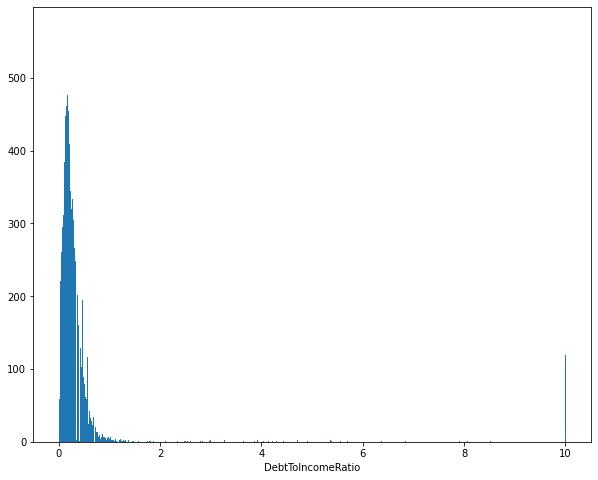

```python
#debt to income ratio
uni_hist('DebtToIncomeRatio',0.01)
```

```python
#Lets check investigate the cluster above 10
High_ratio=Loss_df[Loss_df['DebtToIncomeRatio']>10]
print(High_ratio.IncomeRange.value_counts())
print(High_ratio.StatedMonthlyIncome.describe())
print(df.groupby(['IncomeRange']).StatedMonthlyIncome.mean())
```

```
$1-24,999         84
Not displayed     22
Not employed      12
$50,000-74,999     1
Name: IncomeRange, dtype: int64
count     119.000000
mean       58.823529
std       417.703927
min         0.000000
25%         0.000000
50%         0.000000
75%         0.000000
max      4000.000000
Name: StatedMonthlyIncome, dtype: float64
IncomeRange
$0                    0.000000
$1-24,999          1491.751443
$100,000+         12402.491781
$25,000-49,999     3117.948559
$50,000-74,999     4993.526570
$75,000-99,999     7082.584535
Not displayed      4703.139129
Not employed        151.364764
Name: StatedMonthlyIncome, dtype: float64
```

Over 75% of borrowers with a ratio over 10 have an income less than 1 dollar. Since the income is a decimal point, the ratio debt to income ratio will be inflated regardless of the size of the debt. We can conclude that this is not a data error as the the dictionary confirms. Values above 1000% were capped at 1001%

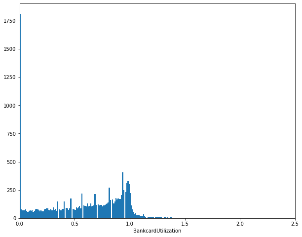

```python
uni_hist('BankcardUtilization', 0.01)
plt.xlim(0,2.5);
```

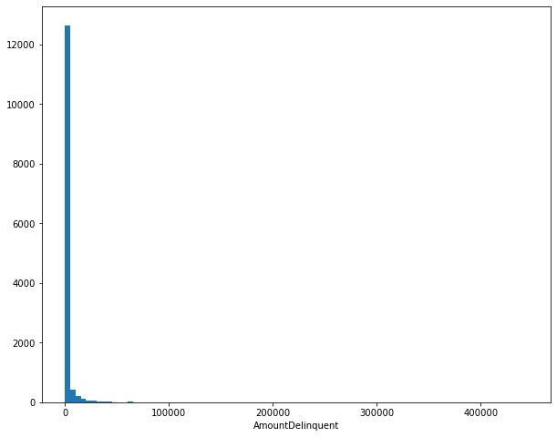

```python
uni_hist('AmountDelinquent',5000)
```

Most of the distribution lies at 0. As we saw with current delinquency most borrowers were clean at the time when they took up the loan. Otherwise the banks lending strategy would be questionable.

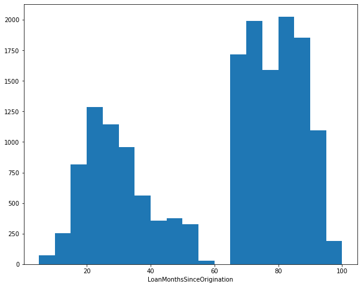

```python
uni_hist('LoanMonthsSinceOrigination',5)
```

The distribution is different before 60 months vs after 60 months.

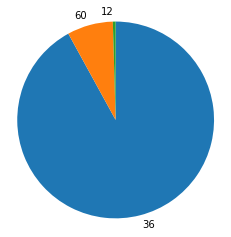

```python
def pie_uni(var):
    plt.pie(Loss_df[var].value_counts(),labels=Loss_df[var].value_counts().index,startangle=90, counterclock=False);
    plt.axis('square')

pie_uni('Term')
```

The distrutibution of loan term could explain why the distribution of LoanMonthsSinceOrigination appears to be bimodal. Loans that fall after 60 months since origination have payments that are past due.

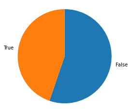

```python
pie_uni('IsBorrowerHomeowner')
```

Under 50% of the borrowers are home owners.

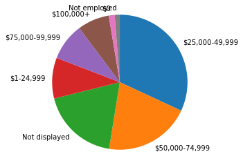

```python
pie_uni('IncomeRange')
```

Most borrowers have an income between 25000 dollars and 75000 dollars.

```python
Loss_df['ListingCategory (numeric)'].value_counts()
```

[output not shown]

```python
#Lets map the ListingCategory codes to the code decribtion and create a count plot
Category_map={
    0 : "Not Available",
    1 : "Debt Consolidation",
    2 : "Home Improvement",
    3 : "Business",
    4 : "Personal Loan",
    5 : "Student Use",
    6 : "Auto",
    7 : "Other",
    8 : "Baby&Adoption",
    9 : "Boat",
    10 : "Cosmetic Procedure",
    11 : "Engagement Ring",
    12 : "Green Loans",
    13 : "Household Expenses",
    14 : "Large Purchases",
    15 : "Medical/Dental",
    16 : "Motorcycle",
    17 : "RV",
    18 : "Taxes",
    19 : "Vacation",
    20 : "Wedding Loans"}
def map_code_to_cat(loan):
    if loan['ListingCategory (numeric)'] in Category_map.keys():
        label=Category_map[loan['ListingCategory (numeric)']]
        return label
    else:
        return loan['ListingCategory (numeric)']
Loss_df['ListingCategory (numeric)']=Loss_df.apply(map_code_to_cat, axis=1)
```

```python
Loss_df['ListingCategory (numeric)'].value_counts()
```

```
Not Available         6633
Debt Consolidation    4588
Other                 1450
Business              1387
Home Improvement       792
Personal Loan          760
Auto                   320
Household Expenses     222
Student Use            189
Medical/Dental         131
Vacation                53
Taxes                   51
Wedding Loans           46
Large Purchases         43
Baby&Adoption           13
Cosmetic Procedure       9
Green Loans              8
Motorcycle               8
Engagement Ring          6
Boat                     3
RV                       1
Name: ListingCategory (numeric), dtype: int64
```

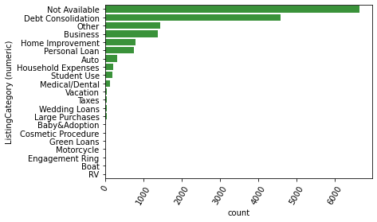

```python
#ListingCategory distribution
sorted_status=Loss_df['ListingCategory (numeric)'].value_counts().index
sb.countplot(data=Loss_df, y='ListingCategory (numeric)', order=sorted_status,color=sb.color_palette()[2])
plt.xticks(rotation=60);
```

### Discuss the distribution(s) of your variable(s) of interest. Were there any unusual points? Did you need to perform any transformations?

> The Prosper score appears to follow a normal distribution due to it's bell shape. The variable did not require any transformation.

### Of the features you investigated, were there any unusual distributions? Did you perform any operations on the data to tidy, adjust, or change the form of the data? If so, why did you do this?

> The distribution of LoanMonthsSinceOrigination seemed unusual, as if two distibutions were plotted on the same axis. The bimodal distribution can be explained by the fact that the loans have terms up to 60 months, after the repayment period has lapsed, defaulted loans will continue to be in arrears for months or years until they are eventually charged off

> The distribution of StatedMonthlyIncome was positioned at the lower end of it's axis, which indicated the presence of outliers. Most of the distribution was at 70,000 or lower, so I trimmed the variable up to 100,000. This excluded two values, one above 100,000 and the second above 200,000.

## Bivariate Exploration

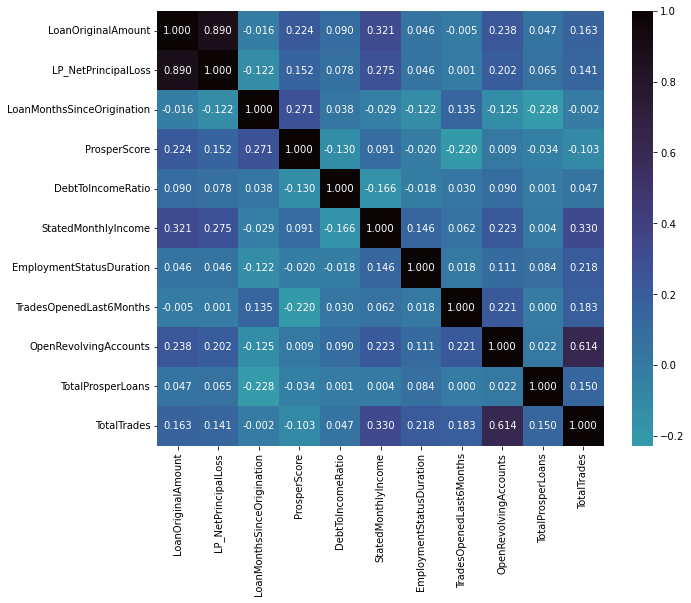

```python
#correlation plot
plt.figure(figsize=[10,8])
quant_vars = ['LoanOriginalAmount', 'LP_NetPrincipalLoss', 'LoanMonthsSinceOrigination','ProsperScore' ,
              'DebtToIncomeRatio', 'StatedMonthlyIncome', 'EmploymentStatusDuration','TradesOpenedLast6Months',
                'OpenRevolvingAccounts','TotalProsperLoans','TotalTrades']
cat_vars = ['IsBorrowerHomeowner', 'Term', 'ListingCategory (numeric)','IncomeRange']
sb.heatmap(Loss_df[quant_vars].corr(), annot = True, fmt = '.3f',cmap = 'mako_r', center = 0);
```

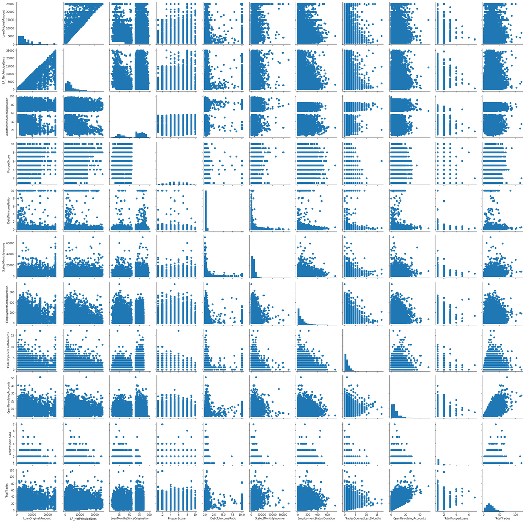

```python
#plot matrix
Loss_df = Loss_df.reset_index(drop=True)
samples = np.random.choice(Loss_df.shape[0], 500, replace = False)
Loss_df_samp = Loss_df.loc[samples,:]
g = sb.PairGrid(data = Loss_df, vars = quant_vars)
g = g.map_diag(plt.hist, bins = 20);
g.map_offdiag(plt.scatter)
```

The pairwise correlation is low for most pairs of variables. LP_NetPrincipalLoss is higly correlated with LoanOriginalAmount and TotalTrades is strongly correlated with OpenRevolvingAccounts. Our main variable of interest Prosper score is not correlated with any of the numeric variables.

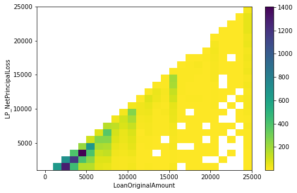

```python
#Further investigation of correlation between LP_NetPrincipalLoss and LoanOriginalAmount
#print(Loss_df[['LP_NetPrincipalLoss','LoanOriginalAmount']].describe())

bins_x=np.arange(-1000,25000+1000,1000)
bins_y=np.arange(1000,25000+1000,1000)
plt.figure(figsize=(8,5))
plt.hist2d(data = Loss_df, x = 'LoanOriginalAmount', y = 'LP_NetPrincipalLoss', cmin=0.1,
           cmap='viridis_r',bins=[bins_x,bins_y])
plt.colorbar()
plt.xlabel('LoanOriginalAmount')
plt.ylabel('LP_NetPrincipalLoss');
```

There is a positive correlation between LoanOriginalAmount and NetPrincipaLoss, as shown by the correlation matrix.

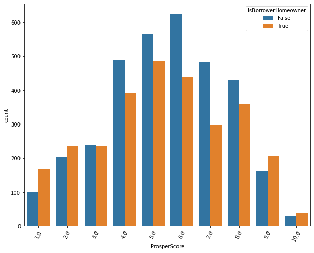

```python
#How does the score distribution compare for home owners vs non-home owners?
plt.figure(figsize=[10,8])
sb.countplot(data=Loss_df, x='ProsperScore', hue='IsBorrowerHomeowner')
plt.xticks(rotation=60);
```

At the highest and lowest two scores Home owers are more than non-home owners.

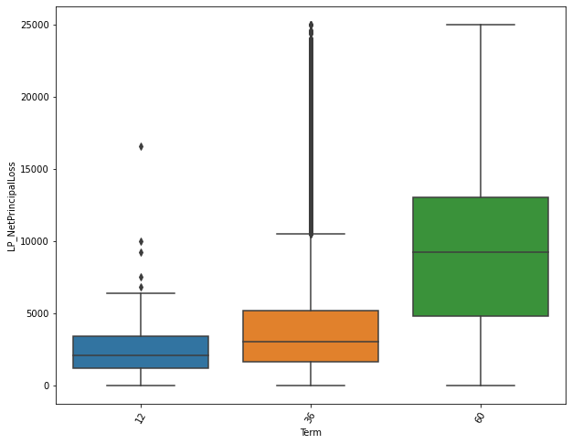

```python
# do loans with a longer payment horizon have a larger net principal loss?
plt.figure(figsize=[10,8])
sb.boxplot(data =Loss_df,x='Term',y='LP_NetPrincipalLoss')
plt.xticks(rotation=60);
```

The median loan amount of the 5 year loan is larger than the upper quartile of the 3-year loan and also larger than the maximum loan amount of the 1 year loan. In addition, the 5 year box plot is the tallest, which suggests a wide range of loss amounts for this type of loan. In contrast the 1 year loan box plot is very short, which tells us that the loss amount range is very narrow and tends to be under 7000 dollars, whereas the 3 year term loan amount can have losses that are twice as much.

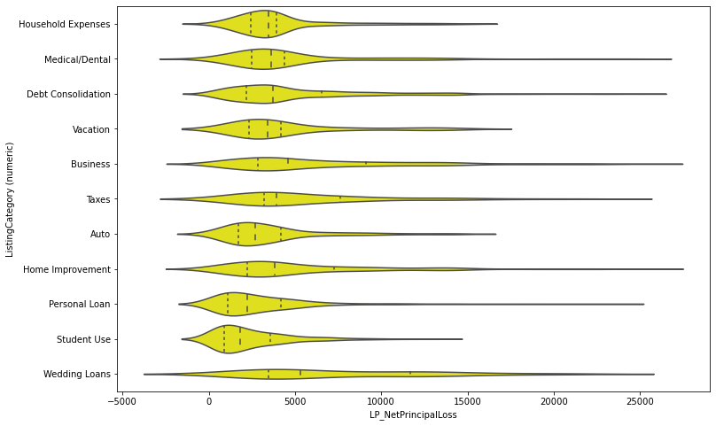

```python
#violin plot of top 10 Listing Category vs LP_NetPrincipalLoss
plt.figure(figsize=[12,8])

Top10Cat=["Debt Consolidation", "Business" ,"Home Improvement","Personal Loan","Auto",
"Household Expenses","Student Use","Medical/Dental","Vacation","Taxes","Wedding Loans" ]

Loss_df['ListingCategory (numeric)'].value_counts()
ListingCategory10=Loss_df[(Loss_df['ListingCategory (numeric)']).isin(Top10Cat) ]


sb.violinplot(data=ListingCategory10,y='ListingCategory (numeric)', x='LP_NetPrincipalLoss',
              color='yellow', inner='quartile');
```

Wedding Loans and business loans have very long tails. This tells us that the the Lender incurs large losses for these type of loans when they default.

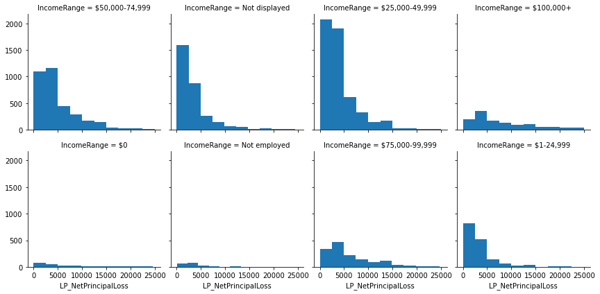

```python
#face grid showing income range vs net loss
f = sb.FacetGrid(data = Loss_df, col = 'IncomeRange', col_wrap = 4,margin_titles=True)
f.map(plt.hist, "LP_NetPrincipalLoss");
```

I would have expected the 0 income and not employed groups to have the largest losses, but this is not the case. All income categories have positively skewed distribitions of varying degrees. The high income earners have a distribution that is almost flat across the different loss bins, while the income ranges under 50,000 have a distrbution thats clustered between 0 and 5000.

### Talk about some of the relationships you observed in this part of the investigation. How did the feature(s) of interest vary with other features in the dataset?

> My main variable of interest Prosper score was not correlated with any of the other variables. But LP_NetPrincipalLoss has some intersting relationships.

### Did you observe any interesting relationships between the other features (not the main feature(s) of interest)?

> LP_NetPrincipalLoss was strongly correlated with Original Loan amount. There was also an interaction between Term and LP_NetPrincipalLoss. The longer the term of the loan the higher the loss amount. This could be a factor of longer term loans having larger repayment amounts. I also saw that certain categories of loans like wedding loans and business loans can be risky for the lender to issue out as the losses can get very large.

## Multivariate Exploration

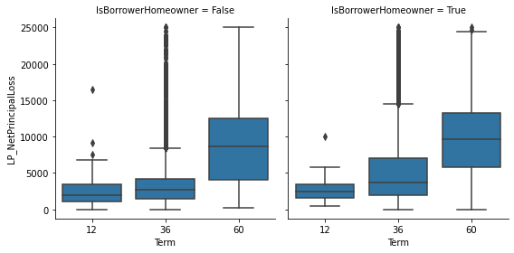

```python
group_means = Loss_df[['Term', 'LP_NetPrincipalLoss']].groupby(['Term']).mean()
group_order = group_means.sort_values(['LP_NetPrincipalLoss'], ascending = False).index

g = sb.FacetGrid(data = Loss_df, col='IsBorrowerHomeowner',height=4)
g.map(sb.boxplot,'Term','LP_NetPrincipalLoss',order=[12,36,60]);
```

For Loans with terms 12 and 60 months, the distribution of losses is the same between home owners and non-home owners. But for 36 month term loans the losses are larger for Home owners.

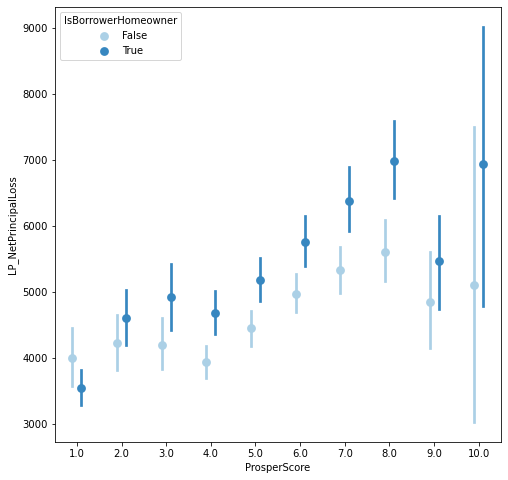

```python
plt.figure(figsize=[8,8])
sb.pointplot(data = Loss_df, x = 'ProsperScore', y = 'LP_NetPrincipalLoss', hue = 'IsBorrowerHomeowner',
           palette = 'Blues', linestyles = '', dodge = 0.2);
```

### Talk about some of the relationships you observed in this part of the investigation. Were there features that strengthened each other in terms of looking at your feature(s) of interest?

> The pointplot of ProsperScore against NetprincipalLoss revealed a relationship between the two variables that was not evident from looking at the correlation matrix and scatter plot. We see that the principal loss amount increases as the Risk rating increases and that home owners have larger loss amounts than non-home owners.

### Were there any interesting or surprising interactions between features?

> Yes, for loans with a term of 36 months, the loss amounts are higher for home owners than non home owners while for other loan terms the losses are the same between the 2 groups.

## Conclusions

> Prosper score is not strongly correlated to any of the other variables in the dataset.

> With certain visualisations, the relationship between the ProsperScore and other variables is hidden due to the size of the data. But when the variables are summarised like in a point plot some relationships do emerge, like how the loss increases as the score increases. This might help Prosper to focus on revising their lending strategy for higher scoring customers to mitigate the loss for this group. And since the loss amount is correlated with Original Loan amount, they could reduce the amount of credit available for certain groups of borrowers.